# Data 624 Project 2

Mary Anna Kivenson

May 3, 2020

## Data

```r
train <- read.csv("https://raw.githubusercontent.com/mkivenson/Predictive-Analytics/master/Project%202/Datasets/student_train.csv")
test <- read.csv("https://raw.githubusercontent.com/mkivenson/Predictive-Analytics/master/Project%202/Datasets/student_test.csv")
```

## Data Exploration

#### Summary

First, we take a look at a summary of the data.

- There are missing values in all of the predictors except for `Pressure.Vacuum` and `Air.Pressurer`
- The target variabale, `PH`, has four missing values that should be removed from the training data
- All predictors except for `Brand.Code` are numeric - `Brand.Code` will be encoded into dummy variables

```r
summary(train)
```

```
##  Brand.Code  Carb.Volume     Fill.Ounces      PC.Volume       Carb.Pressure
##   : 120     Min.   :5.040   Min.   :23.63   Min.   :0.07933   Min.   :57.00
##  A: 293     1st Qu.:5.293   1st Qu.:23.92   1st Qu.:0.23917   1st Qu.:65.60
##  B:1239     Median :5.347   Median :23.97   Median :0.27133   Median :68.20
##  C: 304     Mean   :5.370   Mean   :23.97   Mean   :0.27712   Mean   :68.19
##  D: 615     3rd Qu.:5.453   3rd Qu.:24.03   3rd Qu.:0.31200   3rd Qu.:70.60
##             Max.   :5.700   Max.   :24.32   Max.   :0.47800   Max.   :79.40
##             NA's   :10      NA's   :38      NA's   :39        NA's   :27
##    Carb.Temp          PSC             PSC.Fill         PSC.CO2
##  Min.   :128.6   Min.   :0.00200   Min.   :0.0000   Min.   :0.00000
##  1st Qu.:138.4   1st Qu.:0.04800   1st Qu.:0.1000   1st Qu.:0.02000
##  Median :140.8   Median :0.07600   Median :0.1800   Median :0.04000
##  Mean   :141.1   Mean   :0.08457   Mean   :0.1954   Mean   :0.05641
##  3rd Qu.:143.8   3rd Qu.:0.11200   3rd Qu.:0.2600   3rd Qu.:0.08000
##  Max.   :154.0   Max.   :0.27000   Max.   :0.6200   Max.   :0.24000
##  NA's   :26      NA's   :33        NA's   :23       NA's   :39
##     Mnf.Flow       Carb.Pressure1  Fill.Pressure   Hyd.Pressure1
##  Min.   :-100.20   Min.   :105.6   Min.   :34.60   Min.   :-0.80
##  1st Qu.:-100.00   1st Qu.:119.0   1st Qu.:46.00   1st Qu.: 0.00
##  Median :  65.20   Median :123.2   Median :46.40   Median :11.40
##  Mean   :  24.57   Mean   :122.6   Mean   :47.92   Mean   :12.44
##  3rd Qu.: 140.80   3rd Qu.:125.4   3rd Qu.:50.00   3rd Qu.:20.20
##  Max.   : 229.40   Max.   :140.2   Max.   :60.40   Max.   :58.00
##  NA's   :2         NA's   :32      NA's   :22      NA's   :11
##  Hyd.Pressure2   Hyd.Pressure3   Hyd.Pressure4     Filler.Level
##  Min.   : 0.00   Min.   :-1.20   Min.   : 52.00   Min.   : 55.8
##  1st Qu.: 0.00   1st Qu.: 0.00   1st Qu.: 86.00   1st Qu.: 98.3
##  Median :28.60   Median :27.60   Median : 96.00   Median :118.4
##  Mean   :20.96   Mean   :20.46   Mean   : 96.29   Mean   :109.3
##  3rd Qu.:34.60   3rd Qu.:33.40   3rd Qu.:102.00   3rd Qu.:120.0
##  Max.   :59.40   Max.   :50.00   Max.   :142.00   Max.   :161.2
##  NA's   :15      NA's   :15      NA's   :30       NA's   :20
##   Filler.Speed   Temperature      Usage.cont      Carb.Flow       Density
##  Min.   : 998   Min.   :63.60   Min.   :12.08   Min.   :  26   Min.   :0.240
##  1st Qu.:3888   1st Qu.:65.20   1st Qu.:18.36   1st Qu.:1144   1st Qu.:0.900
##  Median :3982   Median :65.60   Median :21.79   Median :3028   Median :0.980
##  Mean   :3687   Mean   :65.97   Mean   :20.99   Mean   :2468   Mean   :1.174
##  3rd Qu.:3998   3rd Qu.:66.40   3rd Qu.:23.75   3rd Qu.:3186   3rd Qu.:1.620
##  Max.   :4030   Max.   :76.20   Max.   :25.90   Max.   :5104   Max.   :1.920
##  NA's   :57     NA's   :14      NA's   :5       NA's   :2      NA's   :1
```

[output cut: 9 more lines]

```
##  Min.   :0.00240   Min.   : 70.0   Min.   :44.00     Min.   :140.8
##  1st Qu.:0.02200   1st Qu.:100.0   1st Qu.:46.00     1st Qu.:142.2
##  Median :0.03340   Median :120.0   Median :46.00     Median :142.6
##  Mean   :0.04684   Mean   :109.3   Mean   :47.62     Mean   :142.8
##  3rd Qu.:0.06000   3rd Qu.:120.0   3rd Qu.:50.00     3rd Qu.:143.0
##  Max.   :0.40000   Max.   :140.0   Max.   :52.00     Max.   :148.2
##  NA's   :12        NA's   :2       NA's   :12
##     Alch.Rel        Carb.Rel      Balling.Lvl
##  Min.   :5.280   Min.   :4.960   Min.   :0.00
##  1st Qu.:6.540   1st Qu.:5.340   1st Qu.:1.38
##  Median :6.560   Median :5.400   Median :1.48
##  Mean   :6.897   Mean   :5.437   Mean   :2.05
##  3rd Qu.:7.240   3rd Qu.:5.540   3rd Qu.:3.14
##  Max.   :8.620   Max.   :6.060   Max.   :3.66
##  NA's   :9       NA's   :10      NA's   :1
```

```r
train <- drop_na(train, "PH") #remove rows without a PH value
```

#### Correlation Plot

This correlation plot shows high multicollinearity in the dataset.

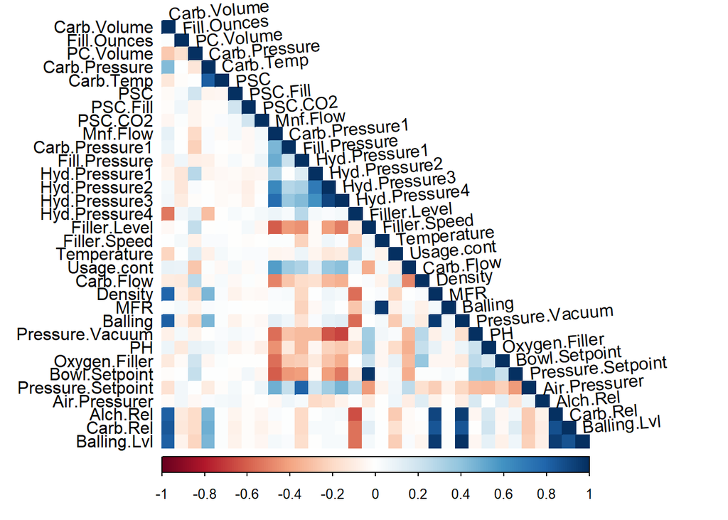

```r
corrplot(cor(subset(train, select = -c(Brand.Code)), use = "complete.obs"), method="color", type="lower", tl.col = "black", tl.srt = 5)
```

## Preprocessing

While performing data exploration, the need for data imputation and encoding was revealed. As part of the preprocessing, these steps will be completed.

#### Encoding

Brand Code is a categorical variable that must be encoded prior to imputation. For each level in the category, a dummy variable is created. Typically, one less predictor than categories is required. However, since there are many missing values in this column, a 0 in each dummy variable corresponds to missing data.

```r
train$Brand.A <- ifelse(train$Brand.Code == 'A', 1, 0)
train$Brand.B <- ifelse(train$Brand.Code == 'B', 1, 0)
train$Brand.C <- ifelse(train$Brand.Code == 'C', 1, 0)
train$Brand.D <- ifelse(train$Brand.Code == 'D', 1, 0)
train <- subset(train, select = -c(Brand.Code))
datatable(train[c("Brand.A", "Brand.B", "Brand.C", "Brand.D")])
```

|  | Brand.A | Brand.B | Brand.C | Brand.D |
| --- | --- | --- | --- | --- |
| 1 | 0 | 1 | 0 | 0 |
| 2 | 1 | 0 | 0 | 0 |
| 3 | 0 | 1 | 0 | 0 |
| 4 | 1 | 0 | 0 | 0 |
| 5 | 1 | 0 | 0 | 0 |
| 6 | 1 | 0 | 0 | 0 |
| 7 | 1 | 0 | 0 | 0 |
| 8 | 0 | 1 | 0 | 0 |
| 9 | 0 | 1 | 0 | 0 |
| 10 | 0 | 1 | 0 | 0 |

[output cut: 2557 more lines]

#### Train Test Split

```r
X_train <- subset(train, select = -c(PH))
y_train <- train$PH
X_test <- subset(test, select = -c(PH))
y_test <- test$PH
```

#### Visualizing Missing Data

The following plots provide a visualization of missing data. There does not seem to be a significant patten in the mising values, and none of the predictors are sparse (highest missing rate is 8%).

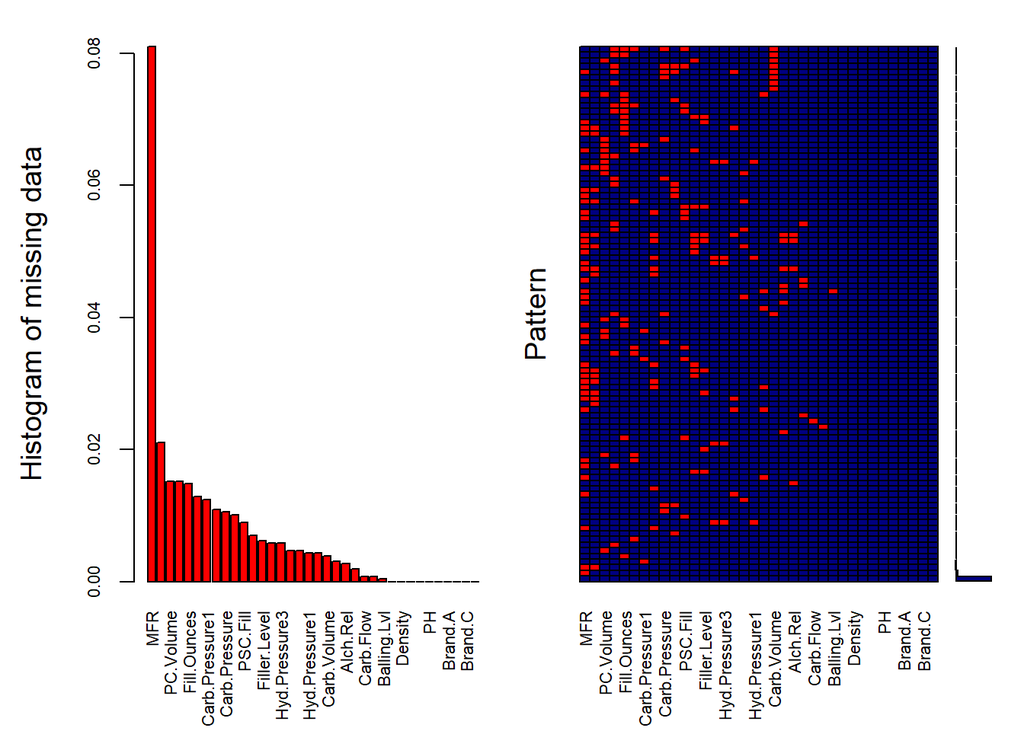

```
##
##  Variables sorted by number of missings:
##           Variable        Count
##                MFR 0.0810284379
##       Filler.Speed 0.0210362291
##          PC.Volume 0.0151928321
##            PSC.CO2 0.0151928321
##        Fill.Ounces 0.0148032723
##                PSC 0.0128554733
##     Carb.Pressure1 0.0124659135
##      Hyd.Pressure4 0.0109076743
##      Carb.Pressure 0.0105181145
##          Carb.Temp 0.0101285547
##           PSC.Fill 0.0089598753
##      Fill.Pressure 0.0070120764
##       Filler.Level 0.0062329568
##      Hyd.Pressure2 0.0058433970
##      Hyd.Pressure3 0.0058433970
##        Temperature 0.0046747176
##  Pressure.Setpoint 0.0046747176
##      Hyd.Pressure1 0.0042851578
##      Oxygen.Filler 0.0042851578
##        Carb.Volume 0.0038955980
##           Carb.Rel 0.0031164784
##           Alch.Rel 0.0027269186
##         Usage.cont 0.0019477990
##          Carb.Flow 0.0007791196
##      Bowl.Setpoint 0.0007791196
##        Balling.Lvl 0.0003895598
##           Mnf.Flow 0.0000000000
##            Density 0.0000000000
##            Balling 0.0000000000
##    Pressure.Vacuum 0.0000000000
##                 PH 0.0000000000
##      Air.Pressurer 0.0000000000
##            Brand.A 0.0000000000
##            Brand.B 0.0000000000
##            Brand.C 0.0000000000
##            Brand.D 0.0000000000
```

```r
aggr(train[,sapply(train, is.numeric)], col=c('navyblue','red'), numbers=TRUE, sortVars=TRUE, labels=names(train), cex.axis=.7, gap=3, ylab=c("Histogram of missing data","Pattern"))
```

#### KNN Imputation

In order to fill missing data, knnImputation will be used. KNN imputation is unsupervised, meaning it does not require a target variable. A train test split was performed earlier so that only predictor data is used for imputation.

```r
result <- preProcess(X_train, method = c("knnImpute"), k = 10)
X_train <- predict(result, X_train)
```

## Linear Models

### Linear Regression

```r
lm <- train(X_train, y_train,
                method = "lm",
                tuneLength = 30,
                trControl = trainControl(method = "cv", 10))
lm
```

```
## Linear Regression
##
## 2567 samples
##   35 predictor
##
## No pre-processing
## Resampling: Cross-Validated (10 fold)
## Summary of sample sizes: 2310, 2310, 2311, 2310, 2311, 2310, ...
## Resampling results:
##
##   RMSE       Rsquared   MAE
##   0.1329494  0.4077779  0.1028825
##
## Tuning parameter 'intercept' was held constant at a value of TRUE
```

### Principal Component Analysis

```r
rlmPCA <- train(X_train, y_train,
                method = "rlm",
                preProcess = "pca",
                tuneLength = 30,
                trControl = trainControl(method = "cv", 10))
rlmPCA
```

```
## Robust Linear Model
##
## 2567 samples
##   35 predictor
##
## Pre-processing: principal component signal extraction (35), centered
##  (35), scaled (35)
## Resampling: Cross-Validated (10 fold)
## Summary of sample sizes: 2309, 2310, 2311, 2311, 2309, 2312, ...
## Resampling results across tuning parameters:
##
##   intercept  psi           RMSE       Rsquared   MAE
##   FALSE      psi.huber     8.5468222  0.3549354  8.5456977
##   FALSE      psi.hampel    8.5468222  0.3549354  8.5456977
##   FALSE      psi.bisquare  8.5468217  0.3549455  8.5456972
##    TRUE      psi.huber     0.1389329  0.3540689  0.1089598
##    TRUE      psi.hampel    0.1387010  0.3553241  0.1093217
##    TRUE      psi.bisquare  0.1389408  0.3540800  0.1089015
##
## RMSE was used to select the optimal model using the smallest value.
## The final values used for the model were intercept = TRUE and psi = psi.hampel.
```

### Partial Least Squares

```r
plsTune <- train(X_train, y_train,
                 method = "pls",
                 tuneLength = 10,
                 trControl = trainControl(method = "cv"))
plsTune
```

```
## Partial Least Squares
##
## 2567 samples
##   35 predictor
##
## No pre-processing
## Resampling: Cross-Validated (10 fold)
## Summary of sample sizes: 2311, 2310, 2310, 2310, 2312, 2311, ...
## Resampling results across tuning parameters:
##
##   ncomp  RMSE       Rsquared   MAE
##    1     0.1496592  0.2491210  0.1188350
##    2     0.1416311  0.3269660  0.1115888
##    3     0.1387773  0.3549088  0.1097609
##    4     0.1370646  0.3704209  0.1080421
##    5     0.1353654  0.3854881  0.1059025
##    6     0.1342459  0.3951727  0.1045765
##    7     0.1336177  0.4009232  0.1039205
##    8     0.1333488  0.4031784  0.1037260
##    9     0.1331430  0.4050793  0.1033611
##   10     0.1329442  0.4068206  0.1031016
##
## RMSE was used to select the optimal model using the smallest value.
## The final value used for the model was ncomp = 10.
```

### Ridge Regression

```r
ridgeGrid <- data.frame(.lambda = seq(0, .1, length = 5))
ridgeRegFit <- train(X_train, y_train,
                     method = "ridge",
                     tuneGrid = ridgeGrid,
                     trControl = trainControl(method = "cv")
                     #preProc = c("center", "scale")
                     )
ridgeRegFit
```

```
## Ridge Regression
##
## 2567 samples
##   35 predictor
##
## No pre-processing
## Resampling: Cross-Validated (10 fold)
## Summary of sample sizes: 2311, 2310, 2309, 2311, 2311, 2311, ...
## Resampling results across tuning parameters:
##
##   lambda  RMSE       Rsquared   MAE
##   0.000   0.1329456  0.4078262  0.1029256
##   0.025   0.1333063  0.4045410  0.1035974
##   0.050   0.1337133  0.4010007  0.1040764
##   0.075   0.1340859  0.3977935  0.1044968
##   0.100   0.1344277  0.3949097  0.1048561
##
## RMSE was used to select the optimal model using the smallest value.
## The final value used for the model was lambda = 0.
```

### Lasso Regression

```r
lassomodel <- train(X_train, y_train,
               method = "lasso",
               trControl = trainControl(method = "cv")
               )
lassomodel
```

```
## The lasso
##
## 2567 samples
##   35 predictor
##
## No pre-processing
## Resampling: Cross-Validated (10 fold)
## Summary of sample sizes: 2310, 2311, 2311, 2312, 2309, 2310, ...
## Resampling results across tuning parameters:
##
##   fraction  RMSE       Rsquared   MAE
##   0.1       0.1501594  0.2906638  0.1189614
##   0.5       0.1340395  0.3995317  0.1044615
##   0.9       0.1331261  0.4062691  0.1030580
##
## RMSE was used to select the optimal model using the smallest value.
## The final value used for the model was fraction = 0.9.
```

### Elastic Net Regression

```r
enetGrid <- expand.grid(.lambda = c(0, 0.05, .3),
                        .fraction = seq(.1, 1, length = 10))

enetTune <- train(X_train, y_train,
                  method = "enet",
                  tuneGrid = enetGrid,
                  trControl = trainControl(method = "cv")
                  #preProc = c("center", "scale")
                  )

enetTune
```

```
## Elasticnet
##
## 2567 samples
##   35 predictor
##
## No pre-processing
## Resampling: Cross-Validated (10 fold)
## Summary of sample sizes: 2311, 2310, 2310, 2311, 2311, 2310, ...
## Resampling results across tuning parameters:
##
##   lambda  fraction  RMSE       Rsquared   MAE
##   0.00    0.1       0.1502123  0.2889262  0.1190627
##   0.00    0.2       0.1411710  0.3451036  0.1116336
##   0.00    0.3       0.1373435  0.3732643  0.1081259
##   0.00    0.4       0.1353678  0.3881327  0.1060069
##   0.00    0.5       0.1341995  0.3976907  0.1046679
##   0.00    0.6       0.1336330  0.4022118  0.1039154
##   0.00    0.7       0.1333862  0.4043529  0.1035214
##   0.00    0.8       0.1332050  0.4060155  0.1032622
##   0.00    0.9       0.1331920  0.4062390  0.1031252
##   0.00    1.0       0.1333073  0.4054437  0.1030583
##   0.05    0.1       0.1561784  0.2569834  0.1242210
##   0.05    0.2       0.1470736  0.3106551  0.1164173
##   0.05    0.3       0.1418885  0.3385391  0.1121822
##   0.05    0.4       0.1389627  0.3590661  0.1097055
##   0.05    0.5       0.1370339  0.3740538  0.1078480
##   0.05    0.6       0.1357945  0.3836835  0.1065542
##   0.05    0.7       0.1349849  0.3904633  0.1056027
##   0.05    0.8       0.1343214  0.3961405  0.1048585
##   0.05    0.9       0.1339053  0.3997474  0.1043670
##   0.05    1.0       0.1337652  0.4010906  0.1041229
##   0.30    0.1       0.1588225  0.2385485  0.1264929
##   0.30    0.2       0.1503180  0.2915162  0.1191828
##   0.30    0.3       0.1448361  0.3185452  0.1146231
##   0.30    0.4       0.1416396  0.3336908  0.1120305
##   0.30    0.5       0.1397021  0.3478657  0.1103337
##   0.30    0.6       0.1383471  0.3589361  0.1089971
##   0.30    0.7       0.1377341  0.3652744  0.1082360
##   0.30    0.8       0.1373993  0.3698985  0.1078340
##   0.30    0.9       0.1370237  0.3745216  0.1074446
##   0.30    1.0       0.1367314  0.3785984  0.1071366
##
## RMSE was used to select the optimal model using the smallest value.
## The final values used for the model were fraction = 0.9 and lambda = 0.
```